# hw10

Alexis Maldonado

11/13/2023

1.a Majority: The final classification will be red since it has 6/10 above 0.5.

Average: The final classification will be green since it has an average that is below 0.5.

1.b if X1 < 1 if X2 < 1 if X1 > 0 if X2 > 0 0 else 10 else 3 else 15 else 5

1.c If x2 < 1 then x2 < 2 will always be true, so -1.06 and 0.21 can be ignored.

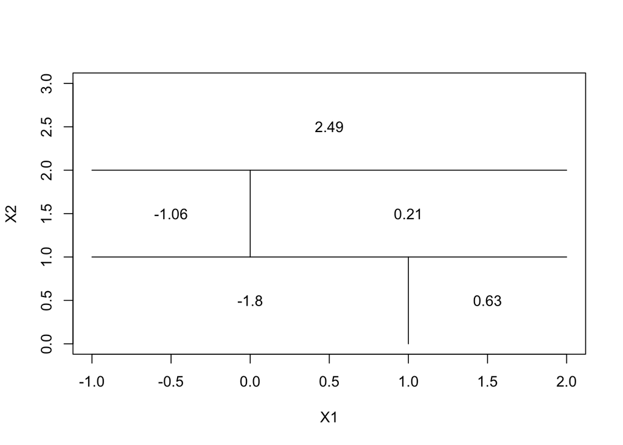

```r
plot(NA, NA, type = "n", xlim = c(-1, 2), ylim = c(0, 3), xlab = "X1", ylab = "X2")
lines(x = c(0, 0), y = c(1, 2))
lines(x = c(-1, 2), y = c(1, 1))
lines(x = c(-1, 2), y = c(2, 2))
lines(x = c(1, 1), y = c(0, 1))
text(x = 0.5, y = 2.5, labels = c(2.49))
text(x = 1.5, y = 0.5, labels = c(0.63))
text(x = 0, y = 0.5, labels = c(-1.8))
text(x = 1, y = 1.5, labels = c(0.21))
text(x = -0.5, y = 1.5, labels = c(-1.06))
```

1.d No bagging can not result in higher variance than an individual tree since bagging takes the average of a bunch of trees it becomes less sensitive to the changes in training data lowering variance from a singular tree.

.———————————————————–

2.a

```r
set.seed(18)
library(ISLR2)
train = sample(1:nrow(OJ),800)
test = OJ[-train, ]
```

2.b 0.1688 training error 7 terminal nodes

```r
library(tree)
tree.oj = tree(Purchase~.,data=OJ, subset=train)
tree.oj
```

```
## node), split, n, deviance, yval, (yprob)
##       * denotes terminal node
##
##  1) root 800 1081.00 CH ( 0.5938 0.4062 )
##    2) LoyalCH < 0.48285 303  320.20 MM ( 0.2211 0.7789 )
##      4) LoyalCH < 0.0356415 54    0.00 MM ( 0.0000 1.0000 ) *
##      5) LoyalCH > 0.0356415 249  290.00 MM ( 0.2691 0.7309 )
##       10) LoyalCH < 0.276142 106   89.96 MM ( 0.1509 0.8491 ) *
##       11) LoyalCH > 0.276142 143  186.30 MM ( 0.3566 0.6434 ) *
##    3) LoyalCH > 0.48285 497  467.20 CH ( 0.8209 0.1791 )
##      6) LoyalCH < 0.764572 237  297.40 CH ( 0.6793 0.3207 )
##       12) PriceDiff < 0.015 77  105.70 MM ( 0.4416 0.5584 )
##         24) ListPriceDiff < 0.235 51   61.79 MM ( 0.2941 0.7059 ) *
##         25) ListPriceDiff > 0.235 26   30.29 CH ( 0.7308 0.2692 ) *
##       13) PriceDiff > 0.015 160  162.90 CH ( 0.7937 0.2062 ) *
##      7) LoyalCH > 0.764572 260  103.20 CH ( 0.9500 0.0500 ) *
```

```r
summary(tree.oj)
```

```
##
## Classification tree:
## tree(formula = Purchase ~ ., data = OJ, subset = train)
## Variables actually used in tree construction:
## [1] "LoyalCH"       "PriceDiff"     "ListPriceDiff"
## Number of terminal nodes:  7
## Residual mean deviance:  0.8001 = 634.5 / 793
## Misclassification error rate: 0.1688 = 135 / 800
```

2.c 13) PriceDiff > 0.015 160 162.90 CH ( 0.7937 0.2062 ) * When priceDiff is greater than 0.015 there is a 79.37 percent chance that CH will be purchased.

2.d For the most part it looks like if LoyalCh is below 0.48 MM will be purchased and if its above Ch will usaully be purchased but no always.

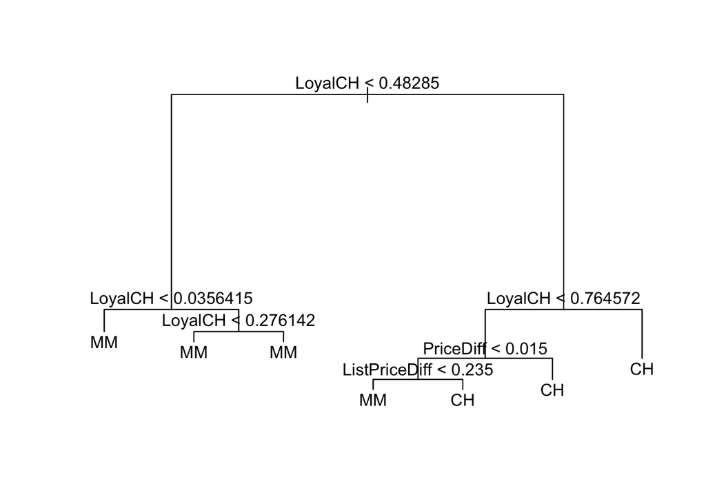

```r
plot(tree.oj)
text(tree.oj,pretty=0)
```

2.e

```r
pred = predict(tree.oj,newdata=test)
Y.test = test$Purchase
mean((as.numeric(pred) - as.numeric(Y.test))^2)
```

```
## [1] 1.062344
```

2.f

```r
set.seed(18)
cv.oj = cv.tree(tree.oj)
cv.oj
```

```
## $size
## [1] 7 6 5 4 3 2 1
##
## $dev
## [1]  745.5052  726.3970  726.3970  765.7772  765.7772  826.9224 1082.5222
##
## $k
## [1]      -Inf  13.60937  13.72554  28.82392  30.16036  66.56244 293.41148
##
## $method
## [1] "deviance"
##
## attr(,"class")
## [1] "prune"         "tree.sequence"
```

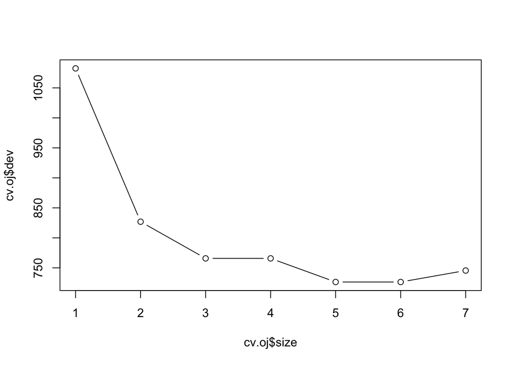

```r
plot(cv.oj$size,cv.oj$dev,type='b')
```

2.g 5 was the smallest optimal size

2.h

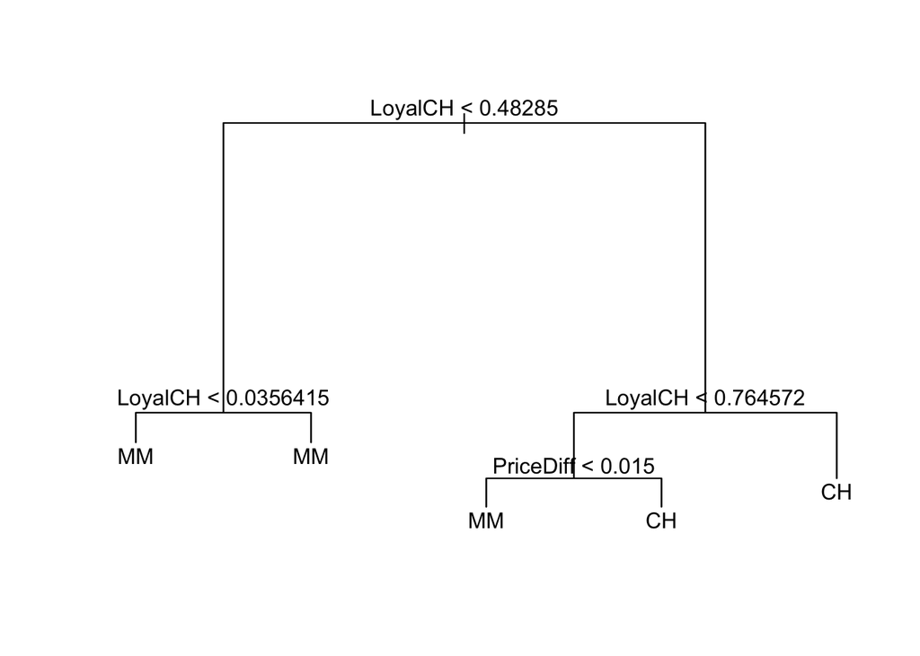

```r
prune.oj = prune.tree(tree.oj,best=5)

plot(prune.oj)
text(prune.oj,pretty=0)
```

2.i The training error in the pruned is higher, is not what we expect but is not too much higher, so it could be okay aslong as it is able consistently to get lower error in the test.

```r
summary(tree.oj)
```

```
##
## Classification tree:
## tree(formula = Purchase ~ ., data = OJ, subset = train)
## Variables actually used in tree construction:
## [1] "LoyalCH"       "PriceDiff"     "ListPriceDiff"
## Number of terminal nodes:  7
## Residual mean deviance:  0.8001 = 634.5 / 793
## Misclassification error rate: 0.1688 = 135 / 800
```

```r
summary(prune.oj)
```

```
##
## Classification tree:
## snip.tree(tree = tree.oj, nodes = c(12L, 5L))
## Variables actually used in tree construction:
## [1] "LoyalCH"   "PriceDiff"
## Number of terminal nodes:  5
## Residual mean deviance:  0.8324 = 661.8 / 795
## Misclassification error rate: 0.1838 = 147 / 800
```

2.j The test error in the pruned is lower, which is was we hope to see meaning the the pruning helped out prediction.

```r
pred = predict(tree.oj,newdata=test)
Y.test = test$Purchase
mean((as.numeric(pred) - as.numeric(Y.test))^2)
```

```
## [1] 1.062344
```

```r
pred = predict(prune.oj,newdata=test)
Y.test = test$Purchase
mean((as.numeric(pred) - as.numeric(Y.test))^2)
```

```
## [1] 1.05186
```

.———————————————————–

3.a

```r
Carseats$High <- factor(ifelse(Carseats$Sales <=8, "No", "Yes"))
cs <- na.omit(Carseats)

train <- sample(1:nrow(cs), 200)
test <- cs[-train, ]
```

3.c

prune.cs = prune.tree(tree.cs,best=5)

3.d

library(randomForest) bag.cs = randomForest(High~.,data=cs, subset = train, mtry = 12, importance = TRUE, ntree=500)

3.h

```r
library(randomForest)
rf.cs = randomForest(High ~., data = cs, mtry = 6, importance = TRUE, ntree = 500, keep.inbag=TRUE)

allpred = predict(rf.cs,newdata=cs,predict.all=TRUE)$individual

n = dim(cs)[1]

yhat = rep(NA,n)
for (i in 1:n) {
 yhat[i] <- as.character(rownames(table(allpred[ , which(rf.cs$inbag[i, ] == 0)]))[which.max(table(allpred[i, which(rf.cs$inbag[i, ] == 0)]))])
}

mean(yhat != cs$High)
```

```
## [1] 0.1875
```